# Continuous-time longitudinal IRT model of PREDIALA study

This vignette illustrates how to estimate a longitudinal IRT following the methodology described in Proust-Lima et al. (2021 - https://arxiv.org/abs/2109.13064). The model combines a graded response measurement model to link a series of ordinal items measured repeatedly over time with their underlying latent process. Simultaneously, a linear mixed model describes the trajectory of the underlying latent process over time.

# Importation

The longitudinal IRT model is estimated via multlcmm function of lcmm R package (Proust-Lima et al. 2017). The following libraries are used in this vignette:

```r
library(lcmm)
library(ggplot2)
library(ggpubr)
library(splines)
library(gridExtra)
library(dplyr)
```

# Dataset

- grp: group with 0=dialyzed and 1=preemptive
- sex: sex with 0=woman and 1=man
- age: age at entry in the cohort
- hads_2 … hads_14 : 7 items of HADS measuring depression
- ID: identification number of the patient
- time: time of measurement (months since entry on the waiting list)
- time_entry: time on the waiting list at entry in the cohort (in months)

```r
str(simdataHADS)
```

```
#> 'data.frame':    1140 obs. of  13 variables:
#>  $ grp       : int  1 0 0 0 0 0 1 0 0 0 ...
#>  $ sex       : int  1 0 0 0 0 0 1 1 1 1 ...
#>  $ age       : num  59.5 58.2 58.2 58.2 58.2 ...
#>  $ hads_2    : int  0 3 1 1 1 2 2 3 3 2 ...
#>  $ hads_4    : int  0 0 0 1 0 1 3 2 2 2 ...
#>  $ hads_6    : int  0 0 1 1 0 1 1 1 2 2 ...
#>  $ hads_8    : int  1 0 1 0 1 1 1 2 1 2 ...
#>  $ hads_10   : int  0 0 2 0 0 1 1 3 1 2 ...
#>  $ hads_12   : int  0 0 0 0 0 1 2 3 3 2 ...
#>  $ hads_14   : int  0 0 0 0 0 0 0 0 0 1 ...
#>  $ ID        : int  1 2 2 2 2 2 3 4 4 4 ...
#>  $ time      : num  7.74 3.18 8.95 15.08 19.74 ...
#>  $ time_entry: num  7.74 3.18 3.18 3.18 3.18 ...
```

## Description of the sample

```r
demo <- simdataHADS %>% group_by(ID) %>% arrange(time) %>%
  filter(row_number()==1)
summary(demo)
```

```
#>       grp              sex              age            hads_2
#>  Min.   :0.0000   Min.   :0.0000   Min.   :55.92   Min.   :0.0000
#>  1st Qu.:0.0000   1st Qu.:0.0000   1st Qu.:58.28   1st Qu.:0.0000
#>  Median :1.0000   Median :1.0000   Median :59.00   Median :1.0000
#>  Mean   :0.5722   Mean   :0.5954   Mean   :58.99   Mean   :0.8806
#>  3rd Qu.:1.0000   3rd Qu.:1.0000   3rd Qu.:59.62   3rd Qu.:1.0000
#>  Max.   :1.0000   Max.   :1.0000   Max.   :61.96   Max.   :3.0000
#>      hads_4           hads_6           hads_8         hads_10
#>  Min.   :0.0000   Min.   :0.0000   Min.   :0.000   Min.   :0.0000
#>  1st Qu.:0.0000   1st Qu.:0.0000   1st Qu.:1.000   1st Qu.:0.0000
#>  Median :0.0000   Median :1.0000   Median :1.000   Median :0.0000
#>  Mean   :0.6613   Mean   :0.6827   Mean   :1.219   Mean   :0.6292
#>  3rd Qu.:1.0000   3rd Qu.:1.0000   3rd Qu.:2.000   3rd Qu.:1.0000
#>  Max.   :3.0000   Max.   :3.0000   Max.   :3.000   Max.   :3.0000
#>     hads_12          hads_14             ID           time
#>  Min.   :0.0000   Min.   :0.0000   Min.   :  1   Min.   : 0.06557
#>  1st Qu.:0.0000   1st Qu.:0.0000   1st Qu.:141   1st Qu.: 2.65574
#>  Median :0.0000   Median :0.0000   Median :281   Median : 5.14754
#>  Mean   :0.6898   Mean   :0.3012   Mean   :281   Mean   : 8.24991
#>  3rd Qu.:1.0000   3rd Qu.:0.0000   3rd Qu.:421   3rd Qu.:11.04918
#>  Max.   :3.0000   Max.   :3.0000   Max.   :561   Max.   :43.14754
#>    time_entry
#>  Min.   : 0.06557
#>  1st Qu.: 2.65574
#>  Median : 5.14754
#>  Mean   : 8.24991
#>  3rd Qu.:11.04918
#>  Max.   :43.14754
```

## Timescale of interest: time on the waiting list

The timescale of interest is the time in months spent on the waiting list: time. This timescale poses two problems:

- As in many studies, entry in the study occurs for each individual at different timings in the progression of the disease. this is called delayed entry. It differs from the usual time in the study where entry corresponds to time 0. Here entry (variable time_entry) corresponds to the duration on the waiting list at inclusion, and time 0 is unlikely observed (i.e., entry in the cohort does not occur as the same time as entry on waiting list).
- The timescale is continuous per se, with as many values as the number of total observations. This prevents the use of methods considering discrete timescales with measurements at the same times for all the individuals, such as classical longitudinal latent variable models.

Distribution of the time at entry and time at follow_ups

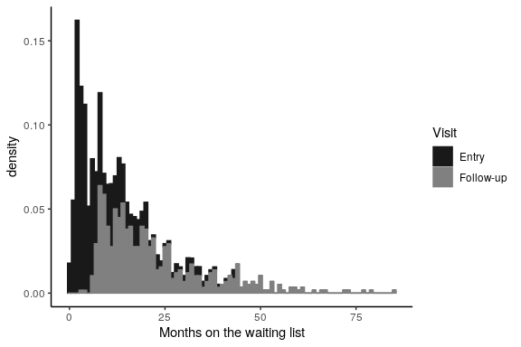

```r
tempSim <- simdataHADS %>% group_by(ID) %>% arrange(time) %>% mutate(Visit=ifelse(time==time_entry,"Entry","Follow-up"))

p <- ggplot(tempSim, aes(x=time,fill=Visit,color=Visit)) + geom_histogram(binwidth=1,aes(y=..density..)) +
  labs(x="Months on the waiting list")
p + scale_color_grey(start = 0.1,
  end = 0.5)+scale_fill_grey(start = 0.1,
  end = 0.5) +
  theme_classic()
```

Quantiles of the distribution of measurement times

```r
quantile(simdataHADS$time,probs=(0:10)/10)
```

```
#>          0%         10%         20%         30%         40%         50%
#>  0.06557377  2.29508190  3.90163950  6.64590183  8.84590190 11.57377100
#>         60%         70%         80%         90%        100%
#> 14.30163940 18.33770480 23.52131100 33.91803170 84.95082100
```

# Continuous-time longitudinal IRT model estimation

We consider here a longitudinal IRT model with natural cubic splines on time on the waiting list to account for a possible nonlinear trajectory over time, and we adjust the trajectory for the group. We consider 2 internal knots placed at 7 and 15, and shift the right boundary at 60 due to the long tail of the distribution. In the main analysis, we estimate a model with no differential item functioning (DIF) on the group and no response shift (RS) on time.

## Estimation of the model with no DIF/RS

To reduce the computation time, we first estimate a model with only 1 random-effect, a random intercept. And then, we use the estimates as initial values for the estimation of the model that also includes random-effects on the time functions. Estimation involves a numerical integration approximated by quasi Monte-Carlo (QMC) with 1000 points. This induces very intensive and long computations but was shown to give accurate results in simulations.

```r
modIRT_i <- multlcmm(hads_2 + hads_4 +hads_6 + hads_8 +hads_10+hads_12 + hads_14 ~ ns(time,knots=c(7,15),Boundary.knots = c(0,60))*grp,random=~1,data=simdataHADS,subject="ID",link="thresholds",methInteg="QMC",nMC=1000)
# use the estimates as initial values - the vector c(0,1,0,0,1,0,0,0,1) initializes the cholesky matrix of the random-effects
Binit <- c(modIRT_i$best[1:7],c(0,1,0,0,1,0,0,0,1),modIRT_i$best[8:length(modIRT_i$best)])

modIRT <- multlcmm(hads_2 + hads_4 +hads_6 + hads_8 +hads_10+hads_12 + hads_14 ~ ns(time,knots=c(7,15),Boundary.knots = c(0,60))*grp,random=~1+ns(time,knots=c(7,15),Boundary.knots = c(0,60)),data=simdataHADS,subject="ID",link="thresholds",methInteg="QMC",nMC=1000, B=Binit)
```

The summary of the estimation:

```r
summary(modIRT)
```

```
#> General latent class mixed model
#>      fitted by maximum likelihood method
#>
#> multlcmm(fixed = hads_2 + hads_4 + hads_6 + hads_8 + hads_10 +
#>     hads_12 + hads_14 ~ ns(time, knots = c(7, 15), Boundary.knots = c(0,
#>     60)) * grp, random = ~1 + ns(time, knots = c(7, 15), Boundary.knots = c(0,
#>     60)), subject = "ID", link = "thresholds", data = simdataHADS,
#>     methInteg = "QMC", nMC = 1000)
#>
#> Statistical Model:
#>      Dataset: simdataHADS
#>      Number of subjects: 561
#>      Number of observations: 7980
#>      Number of latent classes: 1
#>      Number of parameters: 44
#>      Link functions: Thresholds for hads_2
#>                      Thresholds for hads_4
#>                      Thresholds for hads_6
#>                      Thresholds for hads_8
#>                      Thresholds for hads_10
#>                      Thresholds for hads_12
#>                      Thresholds for hads_14
#>
#> Iteration process:
#>      Convergence criteria satisfied
#>      Number of iterations:  30
#>      Convergence criteria: parameters= 2e-08
#>                          : likelihood= 3.2e-06
#>                          : second derivatives= 1.8e-06
#>
#> Goodness-of-fit statistics:
#>      maximum log-likelihood: -7218.96
#>      AIC: 14525.91
#>      BIC: 14716.42
#>
#> Maximum Likelihood Estimates:
#>
#> Fixed effects in the longitudinal model:
#>
#>                                                                coef      Se
```

[output cut: 56 more lines]

```
#> hads_6-Thresh1  -0.38855 0.16408 -2.368 0.01788
#> hads_6-Thresh2   1.35285 0.06836 19.790 0.00000
#> hads_6-Thresh3   1.32439 0.09443 14.025 0.00000
#> hads_8-Thresh1  -1.39105 0.20071 -6.931 0.00000
#> hads_8-Thresh2   1.34308 0.06446 20.836 0.00000
#> hads_8-Thresh3   1.10197 0.05825 18.918 0.00000
#> hads_10-Thresh1 -0.02481 0.16367 -0.152 0.87949
#> hads_10-Thresh2  1.00550 0.05464 18.403 0.00000
#> hads_10-Thresh3  1.10645 0.06561 16.863 0.00000
#> hads_12-Thresh1 -0.20523 0.15916 -1.289 0.19724
#> hads_12-Thresh2  0.99398 0.04808 20.675 0.00000
#> hads_12-Thresh3  1.02543 0.05776 17.753 0.00000
#> hads_14-Thresh1  0.91742 0.20988  4.371 0.00001
#> hads_14-Thresh2  1.49255 0.09869 15.124 0.00000
#> hads_14-Thresh3  0.87180 0.10143  8.595 0.00000
```

## Predicted underlying depressive symptomatolgy trajectory

### plot of predicted mean trajectories

The predicted trajectory of the underlying process can be obtained with predictL function and the associated plot function.

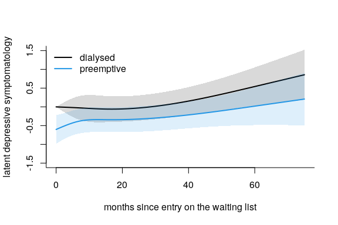

```r
datnew <- data.frame(time = seq(0,75,by=1))
datnew$grp <- 0
pIRT0 <- predictL(modIRT,datnew,var.time="time",confint = T)
datnew$grp <- 1
pIRT1 <- predictL(modIRT,datnew,var.time="time",confint = T)
plot(pIRT0,col=1,lwd=2,ylim=c(-1.5,1.5),legend=NULL,main="",ylab="latent depressive symptomatology",xlab="months since entry on the waiting list",type="l",bty="l",shades=T)
plot(pIRT1,add=T,col=4,lwd=2,shades=T)
legend(x="topleft",legend=c("dialysed","preemptive"),lty=c(1,1),col=c(1,4),lwd=2,bty="n")
```

### Posteriori distribution

To better appreciate the range of the underlying depressive symptomatology, the empirical posterior distribution can be computed

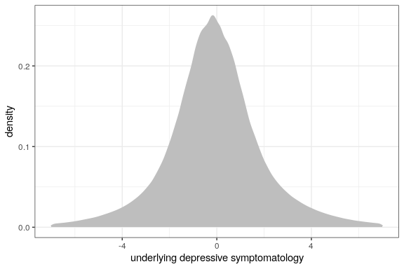

```r
beta <- modIRT$best
t <- 0:72
Z <- cbind(rep(1,length(t)),ns(t,knots=c(7,15),Boundary.knots = c(0,60)))
chol <- matrix(0,ncol=4,nrow=4)
chol[upper.tri(chol, diag = T)] <- c(1,beta[7:15])
library(mvtnorm)
Lambda0 <- rmvnorm(10000,mean = Z%*%c(0,beta[1:3]),Z%*%t(chol)%*%chol%*%t(Z))
Lambda1 <- rmvnorm(10000,mean = Z%*%beta[4:7],Z%*%t(chol)%*%chol%*%t(Z))
Lambda <- data.frame(Lambda = as.vector(rbind(Lambda0,Lambda1)))
phist <- ggplot(Lambda,aes(x=Lambda))+ geom_density(color="grey", fill="grey") + theme_bw() +
  xlab("underlying depressive symptomatology") +xlim(-7,7)
phist
Warning: Removed 14464 rows containing non-finite values (stat_density).
```

The 95% range of the underlying distribution is approximately:

```r
quantile(Lambda$Lambda,p=c(0.025,0.975))
```

```
#>      2.5%     97.5%
#> -4.589935  4.663775
```

## Location and discrimination of the items (with SE by Delta-Method)

The location and discrimination parameters are transformations of the estimated parameters. They are retrieved with the following code:

- isolate the corresponding parameters within the vector of estimated parameters (and the corresponding variance covariance matrix)

```r
## Parameters
nlevel <- 4
nitems <- 7
levels <- rep(nlevel,nitems)
npm <- length(modIRT$best)
seuils <- modIRT$best[(npm-(nlevel-1)*(nitems)+1):(npm)]
err <- abs(modIRT$best[(npm-(nlevel-1)*(nitems)-(nitems-1)):(npm-(nlevel-1)*(nitems))])
seuils
```

```
#>     Thresh1     Thresh2     Thresh3     Thresh1     Thresh2     Thresh3
#> -0.54295998  1.12581248  0.88948647 -0.23896189  1.01286765  1.04561833
#>     Thresh1     Thresh2     Thresh3     Thresh1     Thresh2     Thresh3
#> -0.38854575  1.35284533  1.32439060 -1.39104501  1.34308298  1.10196668
#>     Thresh1     Thresh2     Thresh3     Thresh1     Thresh2     Thresh3
#> -0.02481498  1.00550201  1.10644595 -0.20523446  0.99397714  1.02543122
#>     Thresh1     Thresh2     Thresh3
#>  0.91741673  1.49254985  0.87180230
```

```r
err
```

```
#> std.err 1 std.err 2 std.err 3 std.err 4 std.err 5 std.err 6 std.err 7
#> 0.7868467 0.6346774 1.0343869 1.0107349 1.0554643 0.6790975 1.6385266
```

```r
# Variance
Vseuils <- VarCov(modIRT)[(npm-(nlevel-1)*(nitems)+1):(npm),(npm-(nlevel-1)*(nitems)+1):(npm)]
Verr <- VarCov(modIRT)[(npm-(nlevel-1)*(nitems)-(nitems-1)):(npm-(nlevel-1)*(nitems)),(npm-(nlevel-1)*(nitems)-(nitems-1)):(npm-(nlevel-1)*(nitems))]
```

- retransform these parameters to obtain the locations and the discrimination of each item with corresponding standard deviation (computed via Delta-method)

```r
# generic function
location <- function(min,max,param,Vparam){
  loc <- param[1]
  se <- sqrt(Vparam[1,1])
  param2 <- rep(0,length(param))
  param2[1] <- 1
  if ((max-min)>1) {
    for (l in 1:(max-min-1)) {
      param2[l+1] <- 2*param[l+1]
      loc[l+1] <- loc[l] + param[1+l]^2
      se[l+1] <- sqrt(t(param2) %*%Vparam %*%param2)
    }
  }
  return(c(loc,se))
}
# application
ItemLoc <- sapply(1:nitems,function(k){location(min=0,max=nlevel-1,param=seuils[((nlevel-1)*(k-1)+1):((nlevel-1)*k)],Vparam=Vseuils[((nlevel-1)*(k-1)+1):((nlevel-1)*k),((nlevel-1)*(k-1)+1):((nlevel-1)*k)])})
colnames(ItemLoc) <- paste("Item",(1:nitems)*2)
ItemLoc <- ItemLoc[c(1,4,2,5,3,6),]
rownames(ItemLoc) <- rep(c("Threshold","SE"),nlevel-1)
discrimination <- 1/abs(err)
sediscr <- diag(err^(-2))%*%Verr%*%diag(err^(-2))
```

The 3 thresholds and discrimination estimates of each item are:

```r
t(rbind(ItemLoc,discrimination,Se=sqrt(diag(sediscr))))
```

```
#>           Threshold        SE Threshold        SE Threshold        SE
#> Item 2  -0.54295998 0.1648116 0.7244938 0.1761869  1.515680 0.2184180
#> Item 4  -0.23896189 0.1591583 0.7869390 0.1767165  1.880257 0.2422033
#> Item 6  -0.38854575 0.1640761 1.4416447 0.2220543  3.195655 0.3954593
#> Item 8  -1.39104501 0.2007092 0.4128269 0.1685202  1.627157 0.2307004
#> Item 10 -0.02481498 0.1636731 0.9862193 0.1968426  2.210442 0.2870308
#> Item 12 -0.20523446 0.1591645 0.7827561 0.1782252  1.834265 0.2411234
#> Item 14  0.91741673 0.2098824 3.1451218 0.4376183  3.905161 0.5382206
#>         discrimination         Se
#> Item 2       1.2708956 0.12409358
#> Item 4       1.5756036 0.15681998
#> Item 6       0.9667562 0.10083591
#> Item 8       0.9893791 0.09850672
#> Item 10      0.9474504 0.10031786
#> Item 12      1.4725427 0.14449255
#> Item 14      0.6103044 0.07789280
```

## item category probability curve

The curve of each item category probability according to the underlying level of depressive symptomatology can be obtain usinf the ItemInfo function.

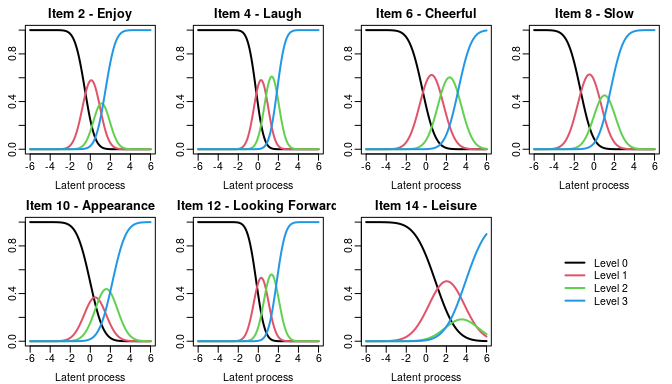

```r
## computations
info_modIRT <- ItemInfo(modIRT, lprocess=seq(-6,6,0.1))

meaning <- c("Enjoy","Laugh","Cheerful" ,"Slow" ,"Appearance" ,"Looking Forward" ,"Leisure")
items <- paste("hads", seq(2,14,2), sep="_")

## automatic graph
par(mfrow=c(2,4), mar=c(3,2,2,1), mgp=c(2,0.5,0))
for(k in 1:7)
{
 plot(info_modIRT, which="LevelProb", outcome=items[k],
      main=paste("Item",2*k,"-",meaning[k]), lwd=2, legend=NULL)
}
plot(0,axes=FALSE, xlab="", ylab="", col="white")
legend("center", legend=paste("Level",0:3), col=1:4, lwd=2, box.lty=0)
```

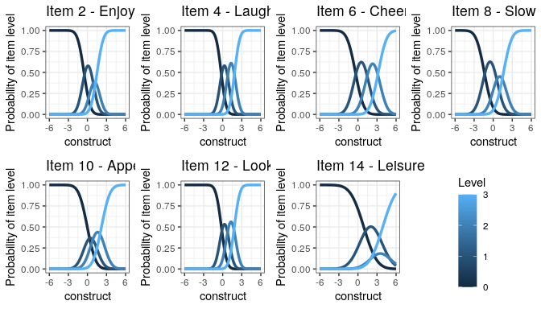

```r
## graph with ggplot
p <- NULL
for (k in 1:7){
ICC  <- info_modIRT$LevelInfo[which(info_modIRT$LevelInfo[,1]==items[k]),]
p[[k]] <- (ggplot(ICC)
      + geom_line(aes(x = Lprocess, y = Prob, group = Level,color=Level), show.legend = F,alpha = 1,size=1.2)
      # + stat_smooth(aes(x = time, y = hads_scorea), method = "loess", size = 0.75)
      + theme_bw()
      + labs(title=paste("Item",2*k,"-",meaning[k]))
      + xlab("construct")
      + ylim(0,1)
      + ylab("Probability of item level"))
}
p[[8]] <- (ggplot(ICC)
      + geom_line(aes(x = Lprocess, y = Prob, group = Level,color=Level),alpha = 1,size=1.2)
      + theme_bw()
)
legend <- get_legend(p[[8]])
grid.arrange(p[[1]],p[[2]],p[[3]],p[[4]],p[[5]],p[[6]],p[[7]],as_ggplot(legend),ncol=4)
```

## Item characteristic curves

The following code computes the expectation of each item according to the underlying level of depressive symptomatology. This is achieved with predictYcond function with two plot possibilities: direct plot function or ggplot

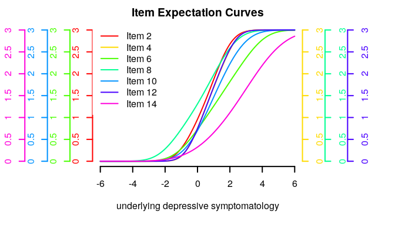

```r
expe <- predictYcond(modIRT,lprocess = seq(-6,6,by=0.1))
# via the internal plot function
plot(expe, xlab="underlying depressive symptomatology", main="Item Expectation Curves",
     legend=paste("Item",(1:nitems)*2), lwd=2)
```

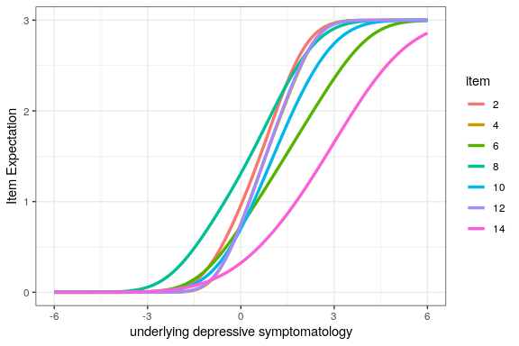

```r
# via ggplot
j <- table(expe$pred$Yname)[1]
expe$pred$item <- as.factor(c(rep(2,j),rep(4,j),rep(6,j),rep(8,j),rep(10,j),rep(12,j),rep(14,j)))
p <- (ggplot(expe$pred)
      + geom_line(aes(x = Lprocess, y = Ypred, group=item,color=item),alpha = 1,size=1.2)
      + theme_bw()
      + xlab("underlying depressive symptomatology")
      + ylim(0,3)
      + ylab("Item Expectation"))
p
```

## Item Information Function

The level of information brought by each item category (information share) and brought in total by each item is also computed by the ItemInfo function. The curves can be again plotted directly with options which=“LevelInfo” and which=“ItemInfo” respectively.

### by Category

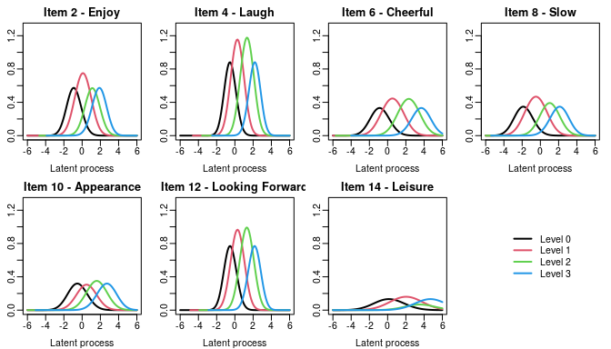

```r
par(mfrow=c(2,4), mar=c(3,2,2,1), mgp=c(2,0.5,0))
for(k in 1:7)
{
 plot(info_modIRT, which="LevelInfo", outcome=items[k],
 main=paste("Item",2*k,"-",meaning[k]), lwd=2, legend=NULL, ylim=c(0,1.3))
}
plot(0,axes=FALSE, xlab="", ylab="", col="white")
legend("center", legend=paste("Level",0:3), col=1:4, lwd=2, box.lty=0)
```

### by Item

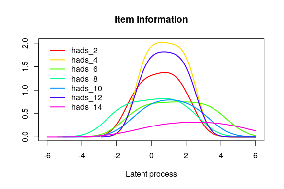

```r
plot(info_modIRT, which="ItemInfo", lwd=2, legend.loc="topleft")
```

## Predicted item trajectory according to time

Item predicted trajectories according to a specific profile of covariates can be computed using predictY function:

```r
head(datnew)
datnew$grp <- 0
ns0 <- predictY(modIRT,var.time = "time",newdata=datnew,methInteg = 1,nsim=2000,draws=T)
datnew$grp <- 1
ns1 <- predictY(modIRT,var.time = "time",newdata=datnew,methInteg = 1,nsim=2000,draws=T)
```

[output not shown]

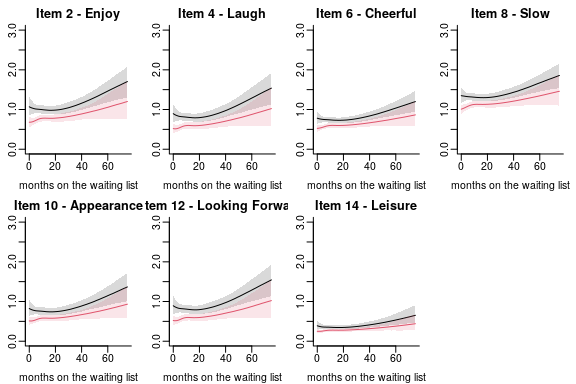

```r
par(mfrow=c(2,4), mar=c(3,2,2,1), mgp=c(2,0.5,0))
for(k in 1:7){
plot(ns0,outcome = k,shades = T,ylim=c(0,3),bty="l",legend=NULL,main=paste("Item",2*k,"-",meaning[k]),ylab="Item level",xlab="months on the waiting list")
plot(ns1,outcome=k,shades=T,add=T,col=2)
}
```

# Assessment of DIF and RS

## Estimation of the IRT model with a DIF on group

DIF is programmed using contrasts (item-specific departure around the mean effect on the underlying latent process)

```r
# initialization of the parameter vector for faster convergence
npm <- length(modIRT$best)
Binit <- c(modIRT$best[1:7],rep(0,(nitems-1)),modIRT$best[(npm-nlevel*nitems-9+1):npm])
# estimation
modIRT_DIFg <- multlcmm(hads_2 + hads_4 +hads_6 + hads_8 +hads_10+hads_12 + hads_14 ~ ns(time,knots=c(7,15),Boundary.knots = c(0,60))*(grp) +contrast(grp),random=~1+ns(time,knots=c(7,15),Boundary.knots = c(0,60)),data=simdataHADS,subject="ID",link="thresholds",methInteg="QMC",nMC=1000,B=Binit)
```

```r
sumDIF <- summary(modIRT_DIFg)
```

```
#> General latent class mixed model
#>      fitted by maximum likelihood method
#>
#> multlcmm(fixed = hads_2 + hads_4 + hads_6 + hads_8 + hads_10 +
#>     hads_12 + hads_14 ~ ns(time, knots = c(7, 15), Boundary.knots = c(0,
#>     60)) * (grp) + contrast(grp), random = ~1 + ns(time, knots = c(7,
#>     15), Boundary.knots = c(0, 60)), subject = "ID", link = "thresholds",
#>     data = simdataHADS, methInteg = "QMC", nMC = 1000)
#>
#> Statistical Model:
#>      Dataset: simdataHADS
#>      Number of subjects: 561
#>      Number of observations: 7980
#>      Number of latent classes: 1
#>      Number of parameters: 50
#>      Link functions: Thresholds for hads_2
#>                      Thresholds for hads_4
#>                      Thresholds for hads_6
#>                      Thresholds for hads_8
#>                      Thresholds for hads_10
#>                      Thresholds for hads_12
#>                      Thresholds for hads_14
#>
#> Iteration process:
#>      Convergence criteria satisfied
#>      Number of iterations:  18
#>      Convergence criteria: parameters= 5.5e-10
#>                          : likelihood= 7.2e-07
#>                          : second derivatives= 3.5e-06
#>
#> Goodness-of-fit statistics:
#>      maximum log-likelihood: -7215.26
#>      AIC: 14530.53
#>      BIC: 14747.01
#>
#> Maximum Likelihood Estimates:
#>
#> Fixed effects in the longitudinal model:
#>
#>                                                                coef      Se
```

[output cut: 75 more lines]

```
#> hads_8-Thresh1  -1.34484 0.18696 -7.193 0.00000
#> hads_8-Thresh2   1.33742 0.06746 19.826 0.00000
#> hads_8-Thresh3   1.09662 0.06048 18.133 0.00000
#> hads_10-Thresh1 -0.05778 0.14266 -0.405 0.68549
#> hads_10-Thresh2  1.01150 0.05570 18.161 0.00000
#> hads_10-Thresh3  1.11286 0.06683 16.653 0.00000
#> hads_12-Thresh1 -0.24864 0.13642 -1.823 0.06837
#> hads_12-Thresh2  1.00115 0.05013 19.970 0.00000
#> hads_12-Thresh3  1.03304 0.05981 17.271 0.00000
#> hads_14-Thresh1  1.01531 0.20581  4.933 0.00000
#> hads_14-Thresh2  1.46240 0.09729 15.032 0.00000
#> hads_14-Thresh3  0.85364 0.09947  8.582 0.00000
#>
#>  ** coefficient not estimated but obtained from the others as minus the sum of them
#>
```

```r
sumDIF[,2]
```

```
#>                                  intercept (not estimated)
#>                                                         NA
#>     ns(time, knots = c(7, 15), Boundary.knots = c(0, 60))1
#>                                                    0.14024
#>     ns(time, knots = c(7, 15), Boundary.knots = c(0, 60))2
#>                                                    0.29380
#>     ns(time, knots = c(7, 15), Boundary.knots = c(0, 60))3
#>                                                    0.22402
#>                                                        grp
#>                                                    0.17193
#> ns(time, knots = c(7, 15), Boundary.knots = c(0, 60))1:grp
#>                                                    0.20130
#> ns(time, knots = c(7, 15), Boundary.knots = c(0, 60))2:grp
#>                                                    0.39851
#> ns(time, knots = c(7, 15), Boundary.knots = c(0, 60))3:grp
#>                                                    0.33328
#>                               Contrasts on grp (p=0.29649)
#>                                                         NA
#>                                                     hads_2
#>                                                    0.05552
#>                                                     hads_4
#>                                                    0.05210
#>                                                     hads_6
#>                                                    0.07969
#>                                                     hads_8
#>                                                    0.06527
#>                                                    hads_10
#>                                                    0.07983
#>                                                    hads_12
#>                                                    0.05426
#>                                                  hads_14**
#>                                                    0.10823
```

Global test for contrasts

```r
WaldMult(modIRT_DIFg,pos=c(8:13))
```

```
#>                                                                                 Wald Test
#> contrast11 = contrast12 = contrast13 = contrast14 = contrast15 = contrast16 = 0   7.27124
#>                                                                                 p_value
#> contrast11 = contrast12 = contrast13 = contrast14 = contrast15 = contrast16 = 0 0.29649
```

95% confidence interval of the difference between groups for item 2:

```r
sum <- summary(modIRT_DIFg)[10,]
```

```
#> General latent class mixed model
#>      fitted by maximum likelihood method
#>
#> multlcmm(fixed = hads_2 + hads_4 + hads_6 + hads_8 + hads_10 +
#>     hads_12 + hads_14 ~ ns(time, knots = c(7, 15), Boundary.knots = c(0,
#>     60)) * (grp) + contrast(grp), random = ~1 + ns(time, knots = c(7,
#>     15), Boundary.knots = c(0, 60)), subject = "ID", link = "thresholds",
#>     data = simdataHADS, methInteg = "QMC", nMC = 1000)
#>
#> Statistical Model:
#>      Dataset: simdataHADS
#>      Number of subjects: 561
#>      Number of observations: 7980
#>      Number of latent classes: 1
#>      Number of parameters: 50
#>      Link functions: Thresholds for hads_2
#>                      Thresholds for hads_4
#>                      Thresholds for hads_6
#>                      Thresholds for hads_8
#>                      Thresholds for hads_10
#>                      Thresholds for hads_12
#>                      Thresholds for hads_14
#>
#> Iteration process:
#>      Convergence criteria satisfied
#>      Number of iterations:  18
#>      Convergence criteria: parameters= 5.5e-10
#>                          : likelihood= 7.2e-07
#>                          : second derivatives= 3.5e-06
#>
#> Goodness-of-fit statistics:
#>      maximum log-likelihood: -7215.26
#>      AIC: 14530.53
#>      BIC: 14747.01
#>
#> Maximum Likelihood Estimates:
#>
#> Fixed effects in the longitudinal model:
#>
#>                                                                coef      Se
```

[output cut: 75 more lines]

```
#> hads_8-Thresh1  -1.34484 0.18696 -7.193 0.00000
#> hads_8-Thresh2   1.33742 0.06746 19.826 0.00000
#> hads_8-Thresh3   1.09662 0.06048 18.133 0.00000
#> hads_10-Thresh1 -0.05778 0.14266 -0.405 0.68549
#> hads_10-Thresh2  1.01150 0.05570 18.161 0.00000
#> hads_10-Thresh3  1.11286 0.06683 16.653 0.00000
#> hads_12-Thresh1 -0.24864 0.13642 -1.823 0.06837
#> hads_12-Thresh2  1.00115 0.05013 19.970 0.00000
#> hads_12-Thresh3  1.03304 0.05981 17.271 0.00000
#> hads_14-Thresh1  1.01531 0.20581  4.933 0.00000
#> hads_14-Thresh2  1.46240 0.09729 15.032 0.00000
#> hads_14-Thresh3  0.85364 0.09947  8.582 0.00000
#>
#>  ** coefficient not estimated but obtained from the others as minus the sum of them
#>
```

```r
c(sum[1],sum[1]- qnorm(0.975)*sum[2],sum[1]+ qnorm(0.975)*sum[2])
```

```
#>       coef       coef       coef
#> -0.0261500 -0.1349672  0.0826672
```